# Analyzing Individual BGG Users

Phil Henrickson

2022-01-02

# **iwantapotato’s** BoardGameGeek Collection

This notebook contains a set of analyses for the selected user’s boardgamegeek collection. The bulk of the analysis is focused on building a user-specific predictive model to predict the games that iwantapotato is likely to own. This enables to ask questions like, based on the games the user currently owns, what games are a good fit for their collection? What upcoming games are they likely to purchase?

This analysis is based on data from BoardGameGeek that was last updated on **2021-12-20.**

# 1 Collection Overview

We can look at a basic description of the number of games that the user owns, has rated, has previously owned, etc.

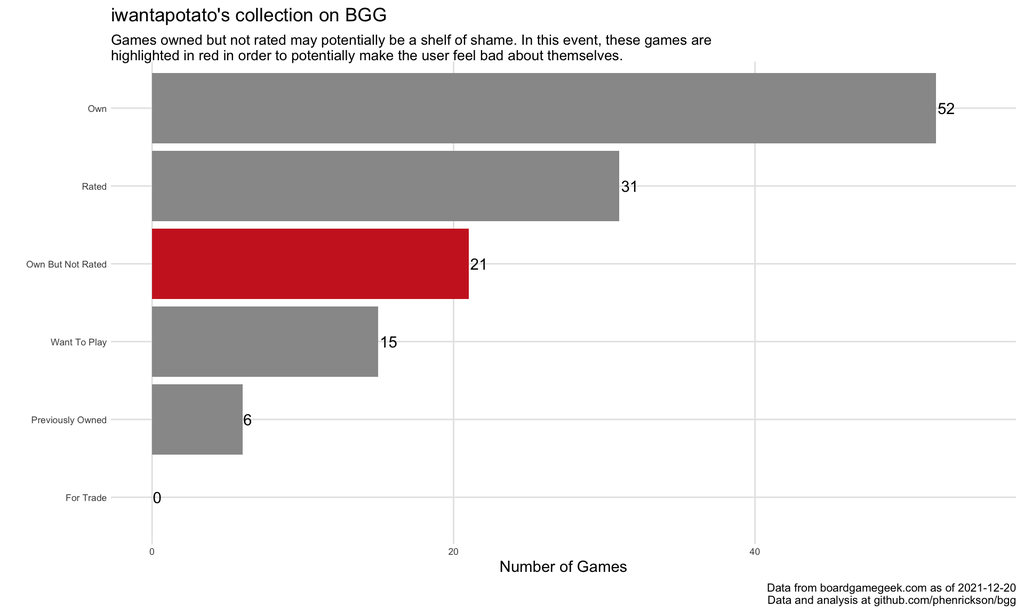

What years has the user owned/rated games from? While we can’t see when a user added or removed a game from their collection, we can look at their collection by the years in which their games were published.

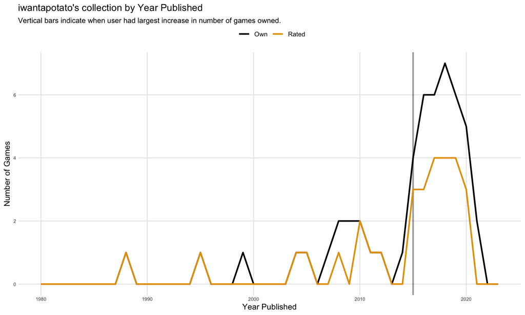

## 1.1 What types of games does iwantapotato own?

We can look at the most frequent types of categories, mechanics, designers, and artists that appear in a user’s collection.

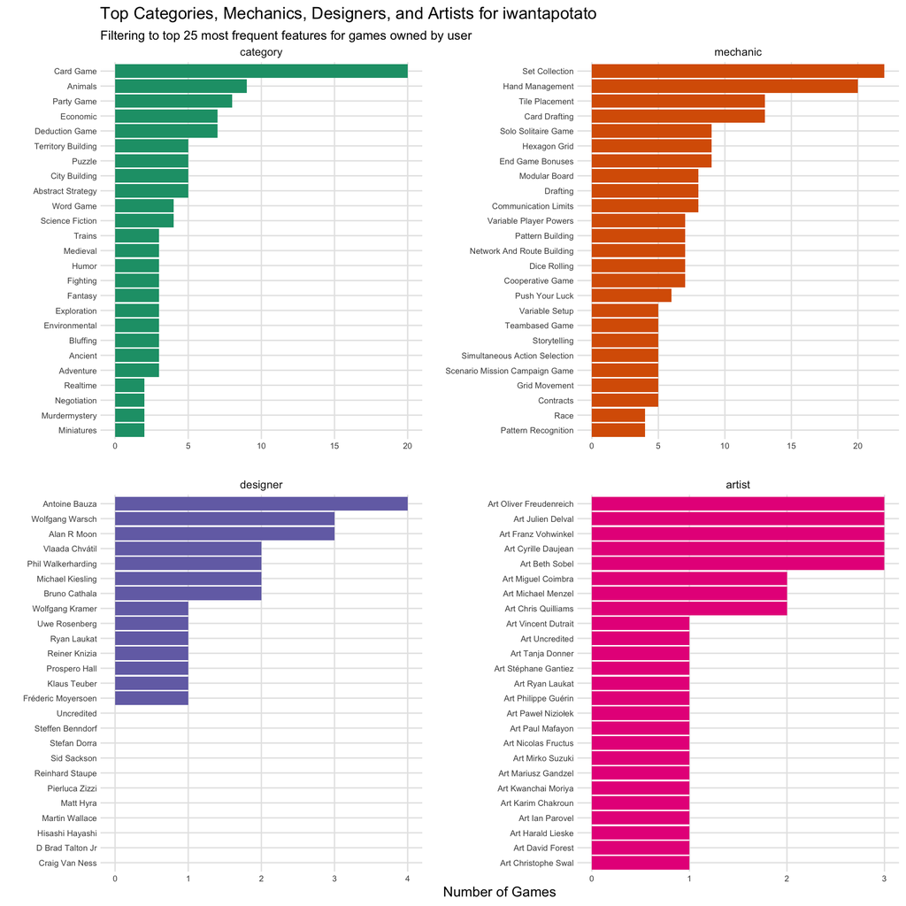

# 2 Modeling **iwantapotato’s** Collection

| username | dataset | period | games_owned | games_rated | games_played |
| --- | --- | --- | --- | --- | --- |
| iwantapotato | training | published before 2020 | 43 | 26 | 48 |
| iwantapotato | test | published 2020 or later | 7 | 3 | 8 |

There are two main (binary) outcomes we will be modeling for the user.

The first, **own** refers to whether the user currently lists a game as owned in their collection. The second, **played** refers to whether the user currently owns, has rated, or previously owned a game. This means the latter will generally have a larger list of games, but may still be a useful category to examine for people who play lots of games without necessarily owning them.

We will train predictive models to learn the probability that the user will own or play individual games based on their features.

## 2.1 Coefficients for iwantapotato

We can examine coefficients from the trained modes, which are penalized logistic regressions fit to our two main outcomes. Positive values indicate that a feature increases a user’s probabilility of owning/rating a game, while negative values indicate a feature decreases the probability.

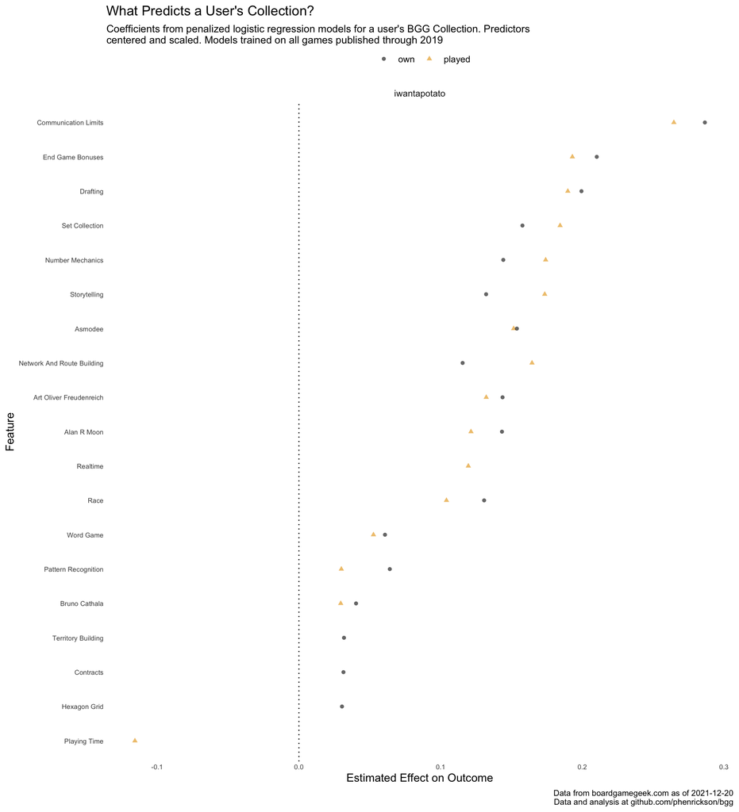

## 2.2 Visualizing Predictors for iwantapotato’s Collection

Why did the model identify these features? We can make density plots of the important features for predicting whether the user owned a game. Blue indicates the density for games owned by the user, while grey indicates the density for games not owned by the user.

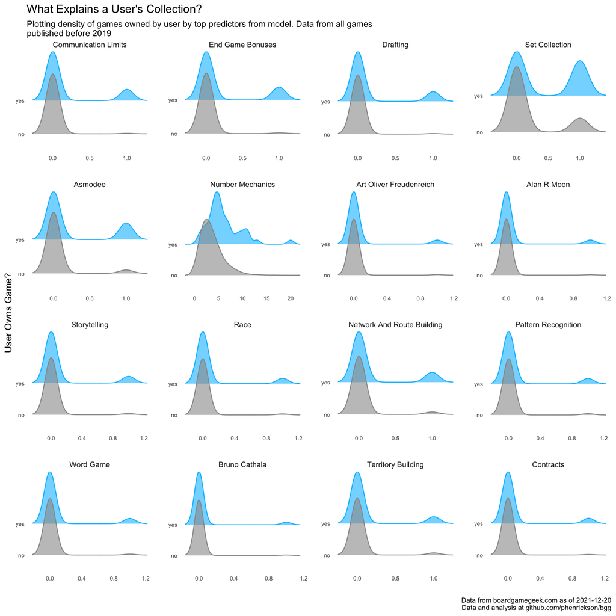

Binary predictors can be difficult to see with this visualization, so we can also directly examine the percentage of games in a user’s collection with a predictor vs the percentage of all games with that predictor.

| username | Feature | % of Games with Feature In_Collection | % of Games with Feature All_Games | Ratio |
| --- | --- | --- | --- | --- |
| iwantapotato | Communication Limits | 18.6% | 0.9% | 20.5 |
| iwantapotato | End Game Bonuses | 20.9% | 1.2% | 17.6 |
| iwantapotato | Drafting | 16.3% | 1.0% | 16.7 |
| iwantapotato | Income | 7.0% | 0.7% | 9.9 |
| iwantapotato | Contracts | 9.3% | 1.0% | 9.3 |
| iwantapotato | Word Game | 9.3% | 1.7% | 5.4 |
| iwantapotato | Storytelling | 11.6% | 2.2% | 5.3 |
| iwantapotato | Race | 9.3% | 1.9% | 5.0 |
| iwantapotato | Asmodee | 25.6% | 5.3% | 4.8 |
| iwantapotato | Network And Route Building | 16.3% | 4.1% | 4.0 |
| iwantapotato | Pattern Recognition | 9.3% | 2.4% | 3.9 |
| iwantapotato | Selfpublished | 4.7% | 1.4% | 3.3 |
| iwantapotato | Territory Building | 11.6% | 3.6% | 3.2 |
| iwantapotato | Puzzle | 9.3% | 3.3% | 2.8 |
| iwantapotato | Set Collection | 44.2% | 17.5% | 2.5 |
| iwantapotato | Hexagon Grid | 16.3% | 6.7% | 2.4 |
| iwantapotato | City Building | 9.3% | 4.3% | 2.2 |
| iwantapotato | Party Game | 14.0% | 8.5% | 1.7 |
| iwantapotato | Racing | 2.3% | 2.8% | 0.8 |
| iwantapotato | Negotiation | 2.3% | 3.7% | 0.6 |
| iwantapotato | CMON Global Limited | 0.0% | 0.8% | 0.0 |
| iwantapotato | Horror | 0.0% | 4.0% | 0.0 |
| iwantapotato | Trivia | 0.0% | 1.8% | 0.0 |
| iwantapotato | Action Dexterity | 0.0% | 4.8% | 0.0 |
| iwantapotato | Mafia | 0.0% | 0.7% | 0.0 |

# 3 Assess Model’s Performance on Training Set

Before predicting games in upcoming years, we can examine how well the model did and what games it liked in the training set. In this case, we used resampling techniques (cross validation) to ensure that the model had not seen a game before making its predictions.

## 3.1 Separation Plot

An easy way to examine the performance of classification model is to view a separation plot. We plot the predicted probabilities from the model for every game (from resampling) from lowest to highest. We then overlay a blue line for any game that the user does own. A good classifier is one that is able to *separate* the blue (games owned by the user) from the white (games not owned by the user), with most of the blue occurring at the highest probabilities (right side of the chart).

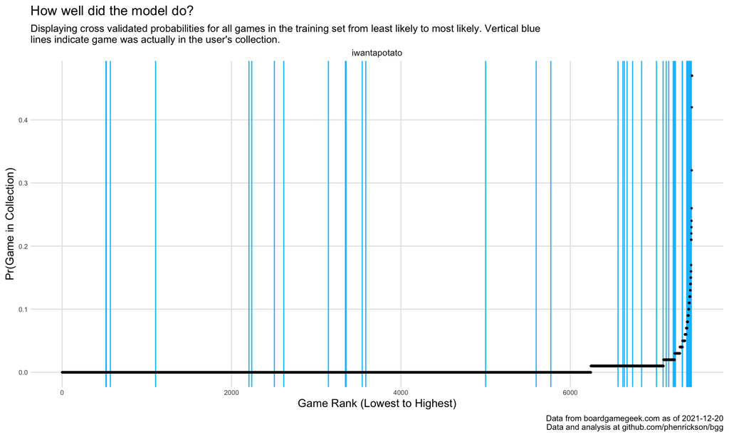

## 3.2 Top Games for **iwantapotato** from Training Set

We can display this information in table form, displaying the 100 games with the highest probability of ownership, adding a blue line when the user does own the game.

| username | yearpublished | game_id | name | pred_played | pred_own | actual_played | actual_own |
| --- | --- | --- | --- | --- | --- | --- | --- |
| iwantapotato | 2019 | 283863 | The Magnificent | 0.41 | 0.47 | 0 | 0 |
| iwantapotato | 2016 | 198454 | When I Dream | 0.59 | 0.47 | 0 | 0 |
| iwantapotato | 2018 | 205896 | Rising Sun | 0.48 | 0.42 | 0 | 0 |
| iwantapotato | 2019 | 260710 | Amul | 0.24 | 0.32 | 0 | 0 |
| iwantapotato | 2014 | 164265 | Witness | 0.10 | 0.26 | 0 | 0 |
| iwantapotato | 2016 | 72321 | The Networks | 0.14 | 0.24 | 0 | 0 |
| iwantapotato | 2013 | 133473 | Sushi Go! | 0.23 | 0.23 | 0 | 0 |
| iwantapotato | 2016 | 167791 | Terraforming Mars | 0.21 | 0.22 | 1 | 1 |
| iwantapotato | 2018 | 246761 | Cahoots | 0.13 | 0.21 | 0 | 0 |
| iwantapotato | 2016 | 205158 | Codenames: Deep Undercover | 0.16 | 0.21 | 0 | 0 |
| iwantapotato | 2017 | 224037 | Codenames: Duet | 0.04 | 0.17 | 1 | 1 |
| iwantapotato | 2012 | 122515 | Keyflower | 0.14 | 0.16 | 0 | 0 |
| iwantapotato | 2019 | 263155 | One Key | 0.08 | 0.16 | 0 | 0 |
| iwantapotato | 2019 | 269603 | Minecraft: Builders & Biomes | 0.12 | 0.15 | 0 | 0 |
| iwantapotato | 2017 | 174430 | Gloomhaven | 0.21 | 0.15 | 1 | 1 |
| iwantapotato | 2018 | 249821 | Codenames: Harry Potter | 0.20 | 0.14 | 0 | 0 |
| iwantapotato | 2018 | 244711 | Newton | 0.23 | 0.14 | 0 | 0 |
| iwantapotato | 2017 | 220775 | Codenames: Disney – Family Edition | 0.23 | 0.14 | 0 | 0 |
| iwantapotato | 2015 | 181304 | Mysterium | 0.10 | 0.14 | 0 | 0 |
| iwantapotato | 2015 | 181687 | The Pursuit of Happiness | 0.11 | 0.13 | 0 | 0 |
| iwantapotato | 2015 | 173090 | The Game | 0.15 | 0.13 | 0 | 0 |
| iwantapotato | 2014 | 163412 | Patchwork | 0.05 | 0.12 | 0 | 0 |
| iwantapotato | 2017 | 220308 | Gaia Project | 0.02 | 0.12 | 0 | 0 |
| iwantapotato | 2017 | 199561 | Sagrada | 0.05 | 0.12 | 0 | 0 |
| iwantapotato | 2018 | 256226 | Azul: Stained Glass of Sintra | 0.09 | 0.12 | 0 | 0 |
| iwantapotato | 2016 | 185589 | Islebound | 0.11 | 0.12 | 0 | 0 |
| iwantapotato | 2019 | 276025 | Maracaibo | 0.15 | 0.12 | 0 | 0 |
| iwantapotato | 2019 | 266192 | Wingspan | 0.13 | 0.12 | 1 | 1 |
| iwantapotato | 2019 | 271324 | It's a Wonderful World | 0.14 | 0.12 | 0 | 0 |
| iwantapotato | 2019 | 261342 | Old West Empresario | 0.07 | 0.11 | 0 | 0 |

[output cut: 70 more lines]

We can also more formally assess how well the model did in resampling by looking at the area under the receiver operating characteristic. A perfect model would receive a score of 1, while a model that cannot predict the outcome will default to a score of 0.5. The extent to which something is a *good* score depends on the setting, but generally anything in the .8 to .9 range is very good while the .7 to .8 range is perfectly acceptable.

| username | outcome_type | .metric | .estimator | .estimate |
| --- | --- | --- | --- | --- |
| iwantapotato | own | roc_auc | binary | 0.838 |
| iwantapotato | played | roc_auc | binary | 0.830 |

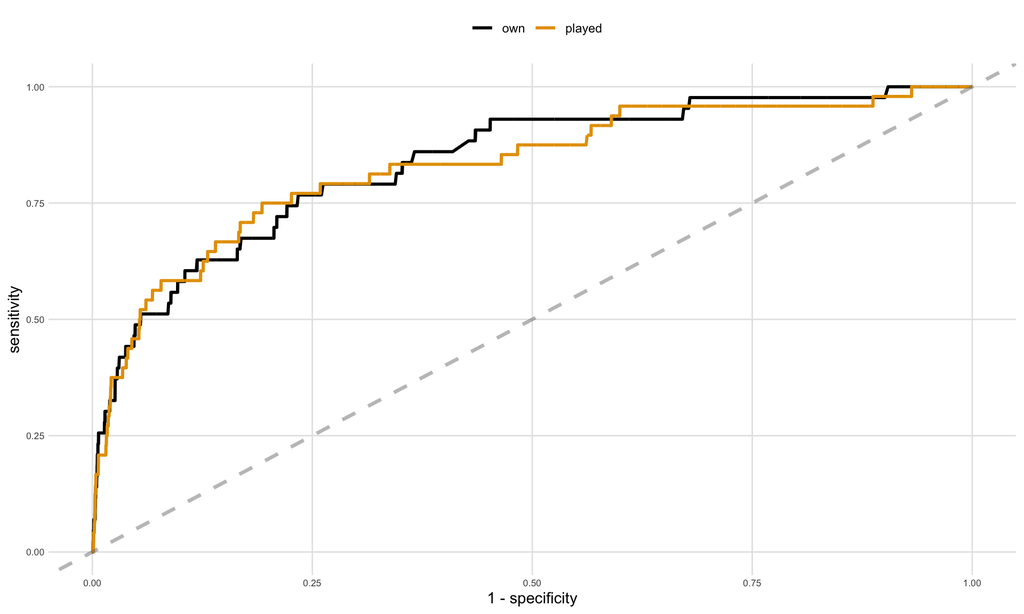

Another way to think about the model performance is to view its lift, or its ability to detect the positive outcomes over that of a null model. High lift indicates the model can much more quickly find all of the positive outcomes (in this case, games owned or played by the user), while a model with no lift is no better than random guessing.

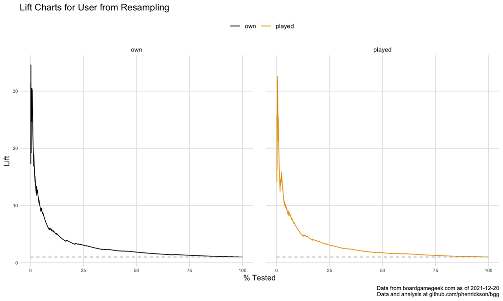

## 3.3 Most and Least Likely Games

What games does the model think iwantapotato is **most likely to own** that are **not** in their collection?

| username | yearpublished | game_id | name | pred_own | actual_own |
| --- | --- | --- | --- | --- | --- |
| iwantapotato | 2019 | 283863 | The Magnificent | 0.47 | 0 |
| iwantapotato | 2016 | 198454 | When I Dream | 0.47 | 0 |
| iwantapotato | 2018 | 205896 | Rising Sun | 0.42 | 0 |
| iwantapotato | 2019 | 260710 | Amul | 0.32 | 0 |
| iwantapotato | 2014 | 164265 | Witness | 0.26 | 0 |

What games does the model think iwantapotato is **least likely to own** that **are** in their collection?

| username | yearpublished | game_id | name | pred_own | actual_own |
| --- | --- | --- | --- | --- | --- |
| iwantapotato | 2009 | 42444 | Batt'l Kha'os | 0 | 1 |
| iwantapotato | 2009 | 54043 | Jaipur | 0 | 1 |
| iwantapotato | 2015 | 173346 | 7 Wonders Duel | 0 | 1 |
| iwantapotato | 1999 | 54 | Tikal | 0 | 1 |
| iwantapotato | 2018 | 244521 | The Quacks of Quedlinburg | 0 | 1 |

## 3.4 Top Games by Year

Top 25 games most likely to be owned by the user in each year, highlighting in blue the games that the user has owned/played.

| rank | 2011 | 2012 | 2013 | 2014 | 2015 | 2016 | 2017 | 2018 | 2019 |
| --- | --- | --- | --- | --- | --- | --- | --- | --- | --- |
| 1 | Takenoko | Keyflower | Sushi Go! | Witness | Mysterium | When I Dream | Codenames: Duet | Rising Sun | The Magnificent |
| 2 | Tragedy Looper | Terra Mystica | Bomb Squad | Patchwork | The Pursuit of Happiness | The Networks | Gloomhaven | Cahoots | Amul |
| 3 | Airlines Europe | Seasons | Concept | Deception: Murder in Hong Kong | The Game | Terraforming Mars | Codenames: Disney – Family Edition | Codenames: Harry Potter | One Key |
| 4 | Rory's Story Cubes: Voyages | The Manhattan Project | Legacy: The Testament of Duke de Crecy | Spyfall | The King Is Dead | Codenames: Deep Undercover | Gaia Project | Newton | Minecraft: Builders & Biomes |
| 5 | Mundus Novus | Targi | Tajemnicze Domostwo | Castles of Mad King Ludwig | 504 | Islebound | Sagrada | Azul: Stained Glass of Sintra | Maracaibo |
| 6 | Village | Il Vecchio | Rory's Story Cubes: Prehistoria | Five Tribes | The Bloody Inn | Sushi Go Party! | Paper Tales | Just One | Wingspan |
| 7 | Mondo | Space Cadets | Circus Train (Second Edition) | La Granja | Between Two Cities | Codenames: Pictures | Bunny Kingdom | The Grizzled: Armistice Edition | It's a Wonderful World |
| 8 | Dixit: Odyssey | Tokaido | The Ravens of Thri Sahashri | Gaïa | The Grizzled | Assembly | Fog of Love | The Mind | Old West Empresario |
| 9 | A Few Acres of Snow | Suburbia | Russian Railroads | Akrotiri | Blood Rage | Agricola (Revised Edition) | Codenames: Marvel | Fuji | Era: Medieval Age |
| 10 | Drako: Dragon & Dwarves | Tzolk'in: The Mayan Calendar | Rory's Story Cubes: Clues | Imperial Settlers | Elfenroads | The Oregon Trail Card Game | Photosynthesis | Gingerbread House | Silver & Gold |
| 11 | Battle of LITS | Among the Stars | Euphoria: Build a Better Dystopia | Sheep & Thief | Nevermore | Yokohama | Ticket to Ride: First Journey (Europe) | Key Flow | Medium |
| 12 | 1911 Amundsen vs Scott | Mondo Sapiens | Voodoo Mania | Spurs: A Tale in the Old West | Far Space Foundry | Hit Z Road | Magic Maze | Blue Lagoon | Letter Jam |
| 13 | Streams | Dark Horse | Brew Crafters | Praetor | Karuba | Beyond Baker Street | Ticket to Ride: Germany | Sherlock: Last Call | Chai |
| 14 | Pantheon | Agents of SMERSH | Dicht dran | Istanbul | Grand Austria Hotel | Capital Lux | Muse | Sherlock: 13 Hostages | Barrage |
| 15 | The Gnomes of Zavandor | Mice and Mystics | Cube Quest | Linko! | Best Treehouse Ever | Junk Art | Mountains of Madness | Narabi | Pictures |
| 16 | Ninjato | Serenissima (Second Edition) | Pizza Party | Hamsterbacke | New Salem | Avenue | The Shipwreck Arcana | Kero | Yōkai |
| 17 | The Secret of Monte Cristo | Spartacus: A Game of Blood and Treachery | The Quiet Year | Saboteur: The Duel | RYŪ | Scythe | Pulsar 2849 | Dice Hospital | Herbaceous Sprouts |
| 18 | Pastiche | Star Trek: Catan | Glass Road | Fields of Arle | Exploding Kittens: NSFW Deck | 13 Days: The Cuban Missile Crisis | Bears vs Babies | Sherlock: Death on the 4th of July | Quirky Circuits |
| 19 | Alcatraz: The Scapegoat | Tahiti | Coal Baron | Deus | ...and then, we held hands. | Inis | Rajas of the Ganges | Sherlock: Paradero Desconocido | Clank!: Legacy – Acquisitions Incorporated |
| 20 | Wiraqocha | Clash of Cultures | Berserk: War of the Realms | Ancient Terrible Things | T.I.M.E Stories | Roll Player | Word Domination | Belratti | Ticket to Ride: London |
| 21 | Mage Knight Board Game | Kairo | Prosperity | La Isla | Haspelknecht | Covalence: A Molecule Building Game | Einstein: His Amazing Life and Incomparable Science | Coimbra | Sherlock: Entre tumbas |
| 22 | Octopus's Garden | Santa Cruz | Dogs | Black Fleet | My Village | Imhotep | Azul | Underwater Cities | Similo |
| 23 | My Happy Farm | Trains | Castle Dice | Artifacts, Inc. | Codenames | Ticket to Ride: First Journey (U.S.) | Near and Far | Cosmic Run: Regeneration | Ecosystem |
| 24 | Kingdom Builder | Uncharted: The Board Game | Salmon Run | Machina Arcana | Drakon (Fourth Edition) | Thief's Market | Facecards | That's Pretty Clever! | Ragusa |
| 25 | 23 | Hooyah: Navy Seals Card Game | Kashgar: Merchants of the Silk Road | Lap Dance | Qwinto | Ticket to Ride: Rails & Sails | Summit: The Board Game | Vengeance | Yukon Airways |

## 3.5 Interactive Predictions from Resampling

Interactive table for predictions from resampling.

|  | username | yearpublished | rank | game_id | name | pred_played | pred_own | actual_played | actual_own |
| --- | --- | --- | --- | --- | --- | --- | --- | --- | --- |
| 1 | iwantapotato | 1900 | 185 | 10799 | Old Maid | 0.04 | 0.03 | 0 | 0 |
| 2 | iwantapotato | 1900 | 358 | 1602 | The Royal Game of Ur | 0.01 | 0.01 | 0 | 0 |
| 3 | iwantapotato | 1900 | 359 | 2399 | Senet | 0.01 | 0.01 | 0 | 0 |
| 4 | iwantapotato | 1900 | 628 | 38950 | Halma | 0.01 | 0.01 | 0 | 0 |
| 5 | iwantapotato | 1900 | 815 | 17003 | Snap | 0 | 0.01 | 0 | 0 |
| 6 | iwantapotato | 1900 | 871 | 15878 | Rummy | 0.01 | 0.01 | 0 | 0 |
| 7 | iwantapotato | 1900 | 921 | 45 | Perudo | 0.01 | 0.01 | 0 | 0 |
| 8 | iwantapotato | 1900 | 928 | 2136 | Pachisi | 0.01 | 0.01 | 0 | 0 |
| 9 | iwantapotato | 1900 | 929 | 2386 | Chinese Checkers | 0.01 | 0.01 | 0 | 0 |
| 10 | iwantapotato | 1900 | 933 | 5432 | Chutes and Ladders | 0.01 | 0.01 | 0 | 0 |

[output cut: 7426 more lines]

# 4 Validating the Model on 2020

How well did a model trained on a user’s collection through 2019 perform in predicting games for the user from 2020?

| username | outcome_type | yearpublished | .metric | .estimator | .estimate |
| --- | --- | --- | --- | --- | --- |
| iwantapotato | own | 2020 | roc_auc | binary | 0.484 |
| iwantapotato | played | 2020 | roc_auc | binary | 0.507 |

Table of top 25 games from 2020, highlighting games that the user owns.

| username | yearpublished | game_id | name | pred_own | pred_played | actual_own | actual_played |
| --- | --- | --- | --- | --- | --- | --- | --- |
| iwantapotato | 2020 | 184267 | On Mars | 0.44 | 0.37 | 0 | 0 |
| iwantapotato | 2020 | 301767 | Mysterium Park | 0.28 | 0.27 | 0 | 0 |
| iwantapotato | 2020 | 291457 | Gloomhaven: Jaws of the Lion | 0.19 | 0.18 | 0 | 0 |
| iwantapotato | 2020 | 307844 | Atheneum: Mystic Library | 0.15 | 0.13 | 0 | 0 |
| iwantapotato | 2020 | 320819 | Dinner in Paris | 0.14 | 0.11 | 0 | 0 |
| iwantapotato | 2020 | 297204 | Traintopia | 0.12 | 0.11 | 0 | 0 |
| iwantapotato | 2020 | 299960 | Alma Mater | 0.11 | 0.09 | 0 | 0 |
| iwantapotato | 2020 | 296498 | 10 Dice | 0.07 | 0.06 | 0 | 0 |
| iwantapotato | 2020 | 302734 | Master Word | 0.07 | 0.23 | 0 | 0 |
| iwantapotato | 2020 | 312786 | Poetry for Neanderthals | 0.07 | 0.23 | 0 | 0 |
| iwantapotato | 2020 | 316377 | 7 Wonders (Second Edition) | 0.06 | 0.07 | 0 | 0 |
| iwantapotato | 2020 | 319966 | The King Is Dead: Second Edition | 0.06 | 0.06 | 0 | 0 |
| iwantapotato | 2020 | 262939 | Far Away | 0.05 | 0.04 | 0 | 0 |
| iwantapotato | 2020 | 288169 | The Fox in the Forest Duet | 0.05 | 0.05 | 0 | 0 |
| iwantapotato | 2020 | 288513 | Tranquility | 0.05 | 0.05 | 0 | 0 |
| iwantapotato | 2020 | 302193 | Wonder Woman: Challenge of the Amazons | 0.05 | 0.04 | 0 | 0 |
| iwantapotato | 2020 | 307002 | Regicide | 0.05 | 0.05 | 0 | 0 |
| iwantapotato | 2020 | 310610 | Sherlock Far West: La Mina Maldita | 0.05 | 0.04 | 0 | 0 |
| iwantapotato | 2020 | 310611 | Sherlock Far West: Disparos al amanecer | 0.05 | 0.04 | 0 | 0 |
| iwantapotato | 2020 | 310612 | Sherlock Far West: Pacto con el diablo | 0.05 | 0.04 | 0 | 0 |
| iwantapotato | 2020 | 313008 | Apollo: A Game Inspired by NASA Moon Missions | 0.05 | 0.04 | 0 | 0 |
| iwantapotato | 2020 | 323784 | Ghost Letters | 0.05 | 0.05 | 0 | 0 |
| iwantapotato | 2020 | 325678 | Sherlock: Ensayos Fabianos | 0.05 | 0.04 | 0 | 0 |
| iwantapotato | 2020 | 325679 | Sherlock: La copia | 0.05 | 0.04 | 0 | 0 |
| iwantapotato | 2020 | 325681 | Sherlock: Asesinato en el Sind Mail | 0.05 | 0.04 | 0 | 0 |

# 5 Predicting Upcoming Games (2020 and On) for **iwantapotato**

Examine the top games for the test set.

| username | yearpublished | game_id | name | rank | own | played |
| --- | --- | --- | --- | --- | --- | --- |
| iwantapotato | 2020 | 184267 | On Mars | 1 | 0.44 | 0.37 |
| iwantapotato | 2020 | 301767 | Mysterium Park | 2 | 0.28 | 0.27 |
| iwantapotato | 2020 | 291457 | Gloomhaven: Jaws of the Lion | 3 | 0.19 | 0.18 |
| iwantapotato | 2020 | 307844 | Atheneum: Mystic Library | 4 | 0.15 | 0.13 |
| iwantapotato | 2020 | 320819 | Dinner in Paris | 5 | 0.14 | 0.11 |
| iwantapotato | 2020 | 297204 | Traintopia | 6 | 0.12 | 0.11 |
| iwantapotato | 2020 | 299960 | Alma Mater | 7 | 0.11 | 0.09 |
| iwantapotato | 2020 | 296498 | 10 Dice | 8 | 0.07 | 0.06 |
| iwantapotato | 2020 | 302734 | Master Word | 9 | 0.07 | 0.23 |
| iwantapotato | 2020 | 312786 | Poetry for Neanderthals | 10 | 0.07 | 0.23 |
| iwantapotato | 2020 | 319966 | The King Is Dead: Second Edition | 11 | 0.06 | 0.06 |
| iwantapotato | 2020 | 316377 | 7 Wonders (Second Edition) | 12 | 0.06 | 0.07 |
| iwantapotato | 2020 | 302193 | Wonder Woman: Challenge of the Amazons | 13 | 0.05 | 0.04 |
| iwantapotato | 2020 | 310610 | Sherlock Far West: La Mina Maldita | 14 | 0.05 | 0.04 |
| iwantapotato | 2020 | 310611 | Sherlock Far West: Disparos al amanecer | 15 | 0.05 | 0.04 |
| iwantapotato | 2020 | 310612 | Sherlock Far West: Pacto con el diablo | 16 | 0.05 | 0.04 |
| iwantapotato | 2020 | 313008 | Apollo: A Game Inspired by NASA Moon Missions | 17 | 0.05 | 0.04 |
| iwantapotato | 2020 | 325678 | Sherlock: Ensayos Fabianos | 18 | 0.05 | 0.04 |
| iwantapotato | 2020 | 325679 | Sherlock: La copia | 19 | 0.05 | 0.04 |
| iwantapotato | 2020 | 325681 | Sherlock: Asesinato en el Sind Mail | 20 | 0.05 | 0.04 |
| iwantapotato | 2020 | 288169 | The Fox in the Forest Duet | 21 | 0.05 | 0.05 |
| iwantapotato | 2020 | 307002 | Regicide | 22 | 0.05 | 0.05 |
| iwantapotato | 2020 | 262939 | Far Away | 23 | 0.05 | 0.04 |
| iwantapotato | 2020 | 323784 | Ghost Letters | 24 | 0.05 | 0.05 |
| iwantapotato | 2020 | 288513 | Tranquility | 25 | 0.05 | 0.05 |
| iwantapotato | 2021 | 298102 | Roll Camera!: The Filmmaking Board Game | 1 | 0.46 | 0.43 |
| iwantapotato | 2021 | 319999 | Dungeon Decorators | 2 | 0.28 | 0.22 |
| iwantapotato | 2021 | 326804 | Rorschach | 3 | 0.11 | 0.08 |
| iwantapotato | 2021 | 315624 | World Changers | 4 | 0.11 | 0.11 |
| iwantapotato | 2021 | 291859 | Riftforce | 5 | 0.11 | 0.11 |
| iwantapotato | 2021 | 309408 | Arcana Rising | 6 | 0.10 | 0.09 |
| iwantapotato | 2021 | 336552 | Mystic Paths | 7 | 0.08 | 0.06 |
| iwantapotato | 2021 | 310873 | Carnegie | 8 | 0.07 | 0.09 |
| iwantapotato | 2021 | 343905 | Boonlake | 9 | 0.06 | 0.04 |
| iwantapotato | 2021 | 329839 | So Clover! | 10 | 0.06 | 0.06 |
| iwantapotato | 2021 | 342942 | Ark Nova | 11 | 0.05 | 0.04 |
| iwantapotato | 2021 | 323118 | Crack the Code | 12 | 0.05 | 0.04 |
| iwantapotato | 2021 | 324856 | The Crew: Mission Deep Sea | 13 | 0.05 | 0.05 |
| iwantapotato | 2021 | 293665 | Ensemble | 14 | 0.05 | 0.05 |
| iwantapotato | 2021 | 252752 | Genotype: A Mendelian Genetics Game | 15 | 0.05 | 0.05 |
| iwantapotato | 2021 | 344408 | Full Throttle! | 16 | 0.05 | 0.05 |
| iwantapotato | 2021 | 300217 | Merchants of the Dark Road | 17 | 0.05 | 0.05 |
| iwantapotato | 2021 | 335541 | We Care: a Grizzled Game | 18 | 0.05 | 0.05 |
| iwantapotato | 2021 | 322014 | All-Star Draft | 19 | 0.04 | 0.04 |
| iwantapotato | 2021 | 319792 | Fly-A-Way | 20 | 0.04 | 0.04 |
| iwantapotato | 2021 | 320992 | The Specialists | 21 | 0.04 | 0.04 |
| iwantapotato | 2021 | 332944 | Sobek: 2 Players | 22 | 0.04 | 0.05 |
| iwantapotato | 2021 | 282776 | Tumble Town | 23 | 0.04 | 0.05 |
| iwantapotato | 2021 | 285967 | Ankh: Gods of Egypt | 24 | 0.03 | 0.02 |
| iwantapotato | 2021 | 313269 | Rescuing Robin Hood | 25 | 0.03 | 0.03 |
| iwantapotato | 2022 | 295770 | Frosthaven | 1 | 0.10 | 0.09 |
| iwantapotato | 2022 | 295374 | Long Shot: The Dice Game | 2 | 0.05 | 0.04 |
| iwantapotato | 2022 | 304051 | Creature Comforts | 3 | 0.05 | 0.05 |
| iwantapotato | 2022 | 280726 | Legacies | 4 | 0.04 | 0.04 |
| iwantapotato | 2022 | 305096 | Endless Winter: Paleoamericans | 5 | 0.04 | 0.03 |
| iwantapotato | 2022 | 317511 | Tindaya | 6 | 0.04 | 0.04 |
| iwantapotato | 2022 | 334065 | Verdant | 7 | 0.04 | 0.04 |
| iwantapotato | 2022 | 331106 | The Witcher: Old World | 8 | 0.03 | 0.02 |
| iwantapotato | 2022 | 335427 | Wild: Serengeti | 9 | 0.03 | 0.03 |
| iwantapotato | 2022 | 326945 | Castles of Mad King Ludwig: Collector's Edition | 10 | 0.03 | 0.03 |
| iwantapotato | 2022 | 345868 | Federation | 11 | 0.02 | 0.02 |
| iwantapotato | 2022 | 324090 | Scarface 1920 | 12 | 0.02 | 0.02 |
| iwantapotato | 2022 | 319807 | Shogun no Katana | 13 | 0.02 | 0.02 |
| iwantapotato | 2022 | 336986 | Flamecraft | 14 | 0.02 | 0.02 |
| iwantapotato | 2022 | 260923 | Titan | 15 | 0.01 | 0.01 |
| iwantapotato | 2022 | 294880 | Chai: Tea for 2 | 16 | 0.01 | 0.01 |
| iwantapotato | 2022 | 284118 | Mechanical Beast | 17 | 0.01 | 0.01 |
| iwantapotato | 2022 | 258779 | Planet Unknown | 18 | 0.01 | 0.01 |
| iwantapotato | 2022 | 270871 | Agemonia | 19 | 0.01 | 0.01 |
| iwantapotato | 2022 | 283137 | Human Punishment: The Beginning | 20 | 0.01 | 0.01 |
| iwantapotato | 2022 | 322289 | Darwin's Journey | 21 | 0.01 | 0.01 |
| iwantapotato | 2022 | 344050 | Dubious | 22 | 0.01 | 0.01 |
| iwantapotato | 2022 | 325494 | ISS Vanguard | 23 | 0.01 | 0.01 |
| iwantapotato | 2022 | 281258 | Sub Terra II: Inferno's Edge | 24 | 0.01 | 0.01 |
| iwantapotato | 2022 | 275284 | Arkeis | 25 | 0.01 | 0.01 |

## 5.1 Interactive Table for Upcoming Games 2020 and On

|  | username | yearpublished | game_id | name | rank | own | played |
| --- | --- | --- | --- | --- | --- | --- | --- |
| 1 | iwantapotato | 2021 | 298102 | Roll Camera!: The Filmmaking Board Game | 1 | 0.46 | 0.43 |
| 2 | iwantapotato | 2020 | 184267 | On Mars | 2 | 0.44 | 0.37 |
| 3 | iwantapotato | 2020 | 301767 | Mysterium Park | 3 | 0.28 | 0.27 |
| 4 | iwantapotato | 2021 | 319999 | Dungeon Decorators | 4 | 0.28 | 0.22 |
| 5 | iwantapotato | 2020 | 291457 | Gloomhaven: Jaws of the Lion | 5 | 0.19 | 0.18 |
| 6 | iwantapotato | 2020 | 307844 | Atheneum: Mystic Library | 6 | 0.15 | 0.13 |
| 7 | iwantapotato | 2020 | 320819 | Dinner in Paris | 7 | 0.14 | 0.11 |
| 8 | iwantapotato | 2020 | 297204 | Traintopia | 8 | 0.12 | 0.11 |
| 9 | iwantapotato | 2021 | 326804 | Rorschach | 9 | 0.11 | 0.08 |
| 10 | iwantapotato | 2021 | 315624 | World Changers | 10 | 0.11 | 0.11 |

[output cut: 1627 more lines]